# | 米饭四溅

# BIOS 545 - 2019 - Lecture 2: Variables, Objects, Vectors

Ziyi Li (ziyi.li@emory.edu)

## Topics today

### 1. Variables

### 2. Dates

### 3. Logical

### 4. Interrogation/Coercion

### 5. Vectors

## 1. Variables

Everything in R is an object, which has a type and belongs to a class. There are functions that will help you figure out what it is you are working with

```r
# Variables

3+5
```

```
## [1] 8
```

```r
typeof(3)
```

```
## [1] "double"
```

```r
class(3)
```

```
## [1] "numeric"
```

```r
typeof(`+`)
```

```
## [1] "builtin"
```

#### The **str** function does a really good job of telling you what the type and structure of an object is. Use it frequently ! (I do).

```r
myvec <- 1:10

str(myvec)
```

```
##  int [1:10] 1 2 3 4 5 6 7 8 9 10
```

```r
str(mtcars)
```

```
## 'data.frame':    32 obs. of  11 variables:
##  $ mpg : num  21 21 22.8 21.4 18.7 18.1 14.3 24.4 22.8 19.2 ...
##  $ cyl : num  6 6 4 6 8 6 8 4 4 6 ...
##  $ disp: num  160 160 108 258 360 ...
##  $ hp  : num  110 110 93 110 175 105 245 62 95 123 ...
##  $ drat: num  3.9 3.9 3.85 3.08 3.15 2.76 3.21 3.69 3.92 3.92 ...
##  $ wt  : num  2.62 2.88 2.32 3.21 3.44 ...
##  $ qsec: num  16.5 17 18.6 19.4 17 ...
##  $ vs  : num  0 0 1 1 0 1 0 1 1 1 ...
##  $ am  : num  1 1 1 0 0 0 0 0 0 0 ...
##  $ gear: num  4 4 4 3 3 3 3 4 4 4 ...
##  $ carb: num  4 4 1 1 2 1 4 2 2 4 ...
```

#### There are four primary variable classes:

- **numeric**
- **character**
- **dates**
- **factors**

#### First we will take a look at numeric data types:

```r
var1 <-3
var1
```

```
## [1] 3
```

```r
sqrt(var1)
```

```
## [1] 1.732051
```

```r
var1 <- 33.3

str(var1)
```

```
##  num 33.3
```

```r
var1 + var1
```

```
## [1] 66.6
```

```r
var1 * var1
```

```
## [1] 1108.89
```

#### There is a difference between real and integer values.

```r
aa <- 5

str(aa)
```

```
##  num 5
```

```r
aa <- as.integer(aa)

str(aa)
```

```
##  int 5
```

```r
aa <- 5.67

as.integer(aa)
```

```
## [1] 5
```

#### Character strings usually represent qualitative variables. Many R functions will usually convert character variables into factors if necessary but not always. (We will discuss factors soon enough)

```r
var.one <- "Hello there ! My name is Ziyi."

var.two <- "How do you do ?"

var.one
```

```
## [1] "Hello there ! My name is Ziyi."
```

```r
nchar(var.one) # Number of characters present
```

```
## [1] 30
```

```r
toupper(var.one)
```

```
## [1] "HELLO THERE ! MY NAME IS ZIYI."
```

```r
mydna <- c("A","G","T","C","A")

str(mydna)
```

```
##  chr [1:5] "A" "G" "T" "C" "A"
```

```r
mydna
```

```
## [1] "A" "G" "T" "C" "A"
```

```r
pi <- "3.14"

str(pi)
```

```
##  chr "3.14"
```

```r
pi + pi
```

```
## Error in pi + pi: non-numeric argument to binary operator
```

```r
# Combining Strings
paste(var.one, var.two)
```

```
## [1] "Hello there ! My name is Ziyi. How do you do ?"
```

```r
paste(var.one, var.two, sep=":")
```

```
## [1] "Hello there ! My name is Ziyi.:How do you do ?"
```

```r
strsplit(var.one, " ")
```

```
## [[1]]
## [1] "Hello" "there" "!"     "My"    "name"  "is"    "Ziyi."
```

```r
patientid <- "ID:011472:M:C" # Encodes Birthday, Gender, and Race

strsplit(patientid, ":")
```

```
## [[1]]
## [1] "ID"     "011472" "M"      "C"
```

```r
bday <- strsplit(patientid, ":")[[1]][2] # Get just the birthday
```

## 2. Dates

#### R has a builtin function called `Sys.Date()` that can tell you the date. It looks like it returns just a character string but it returns a true date object. (Use str when in doubt). But `Sys.Date()` doesn’t help us convert strings to dates.

```r
Sys.Date()
```

```
## [1] "2019-02-15"
```

```r
Sys.Date() + 1
```

```
## [1] "2019-02-16"
```

```r
str(Sys.Date())
```

```
##  Date[1:1], format: "2019-02-15"
```

#### So unless you tell R that a string is in fact a ``real’’ date it will assume that it is simply a character string.

```r
somedate <- "03/17/99"

str(somedate)
```

```
##  chr "03/17/99"
```

```r
somedate+1
```

```
## Error in somedate + 1: non-numeric argument to binary operator
```

```r
realdate <- as.Date("03/17/99","%m/%d/%y")

str(realdate)
```

```
##  Date[1:1], format: "1999-03-17"
```

```r
realdate+1
```

```
## [1] "1999-03-18"
```

#### The `as.Date()` function handles dates involving years, months, and days. It does not handle times. It is easy to use once you learn the tokens.

```r
as.Date("January 01 2010","%B %d %Y")
```

```
## [1] "2010-01-01"
```

```r
as.Date("Jan 01, 2010","%b %d, %Y")
```

```
## [1] "2010-01-01"
```

```r
as.Date("01/01/10","%m/%d/%y")
```

```
## [1] "2010-01-01"
```

```r
as.Date("1Jan2010","%d%b%Y")
```

```
## [1] "2010-01-01"
```

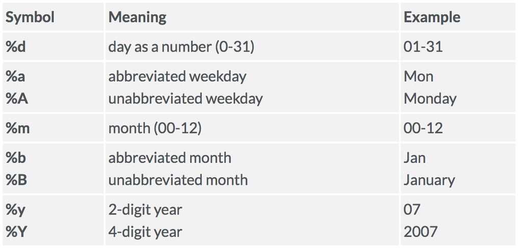

#### Once dates have been converted we can perform arithmetic and logical operations on them.

```r
date1 <- as.Date("03/17/08","%m/%d/%y")

date2 <- as.Date("04/17/08","%m/%d/%y")

date2 - date1
```

```
## Time difference of 31 days
```

```r
mean(c(date1,date2))
```

```
## [1] "2008-04-01"
```

```r
date2 < date1
```

```
## [1] FALSE
```

```r
date2 > date1
```

```
## [1] TRUE
```

#### This function can help us convert columns in a data frame that contain dates as character strings

```r
mydf <- data.frame(measure=round(rnorm(4),2),
                  date=c("01/23/01","02/20/01","02/22/01","03/04/01"))
str(mydf)
```

```
## 'data.frame':    4 obs. of  2 variables:
##  $ measure: num  0.69 -1.37 0.26 0.15
##  $ date   : Factor w/ 4 levels "01/23/01","02/20/01",..: 1 2 3 4
```

```r
mydf$date
```

```
## [1] 01/23/01 02/20/01 02/22/01 03/04/01
## Levels: 01/23/01 02/20/01 02/22/01 03/04/01
```

```r
mydf$date <- as.Date(mydf$date,"%m/%d/%y")
str(mydf$date)
```

```
##  Date[1:4], format: "2001-01-23" "2001-02-20" "2001-02-22" "2001-03-04"
```

#### There are some helper functions that make it easy to figure out the month name of a series of dates or whether a given date represents a weekday.

```r
months(mydf$date)
```

```
## [1] "January"  "February" "February" "March"
```

```r
weekdays(mydf$date)
```

```
## [1] "Tuesday"  "Tuesday"  "Thursday" "Sunday"
```

```r
quarters(mydf$date)
```

```
## [1] "Q1" "Q1" "Q1" "Q1"
```

```r
table(months(mydf$date))
```

```
##
## February  January    March
##        2        1        1
```

#### Let’s revisit this example to show why any of this matters:

```r
mydf <- data.frame(measure = round(rnorm(4),2),date = c("01/23/01",
                                                    "02/20/01","02/22/01","03/04/01"))

str(mydf)
```

```
## 'data.frame':    4 obs. of  2 variables:
##  $ measure: num  1.96 -0.83 -1.61 -1.09
##  $ date   : Factor w/ 4 levels "01/23/01","02/20/01",..: 1 2 3 4
```

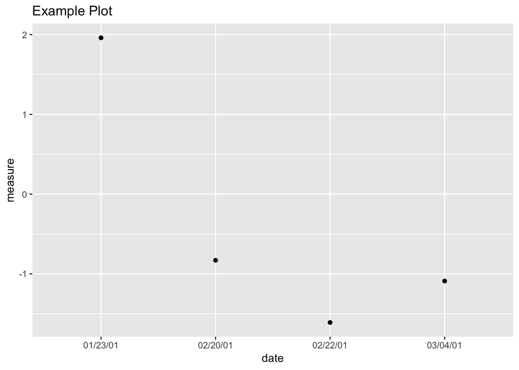

```r
library(ggplot2)
## before date conversion
ggplot(data = mydf,aes(x = date,y = measure)) +
  geom_point() + ggtitle("Example Plot")
```

```r
mydf$date <- as.Date(mydf$date,"%m/%d/%y")
str(mydf$date)
```

```
##  Date[1:4], format: "2001-01-23" "2001-02-20" "2001-02-22" "2001-03-04"
```

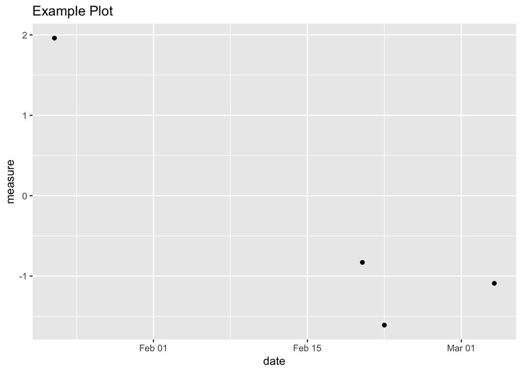

```r
## after date conversion
ggplot(data=mydf,aes(x = date,y = measure)) +
  geom_point() + ggtitle("Example Plot")
```

### Another useful tool to process dates: function `strptime()`:

```r
strptime("1945-11-04","%Y-%m-%d")
```

```
## [1] "1945-11-04 EST"
```

```r
strptime("Tuesday March 17, 2011 01:10:05","%A %B %d, %Y %H:%M:%S")
```

```
## [1] "2011-03-17 01:10:05 EDT"
```

```r
strptime("11/14/45 10:10:00 AM","%m/%d/%y %I:%M:%S %p")
```

```
## [1] "2045-11-14 10:10:00 EST"
```

```r
strptime("11/14/45 10:10:00 PM","%m/%d/%y %I:%M:%S %p")
```

```
## [1] "2045-11-14 22:10:00 EST"
```

```r
date1 <- strptime("11/14/45 10:10:00 AM","%m/%d/%y %I:%M:%S %p")

date2 <- strptime("11/14/45 10:10:00 PM","%m/%d/%y %I:%M:%S %p")

date2 - date1
```

```
## Time difference of 12 hours
```

```r
difftime(date2,date1)
```

```
## Time difference of 12 hours
```

```r
# We can convert many dates at once

strptime(c("03/27/2003","03/27/2003","04/14/2008"),format="%m/%d/%Y")
```

```
## [1] "2003-03-27 EST" "2003-03-27 EST" "2008-04-14 EDT"
```

#### Since strptime handles times as well as dates you will need to know the tokens necessary to process times. The tokens to process dates are the same as with `as.Date()`.

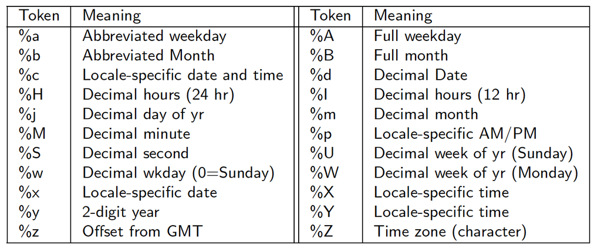

#### We can also easily generate sequences of dates if necessary.

```r
start_date <- strptime('01/10/2011','%m/%d/%Y')

seq(start_date,by=5,length=3)
```

```
## [1] "2011-01-10 00:00:00 EST" "2011-01-10 00:00:05 EST"
## [3] "2011-01-10 00:00:10 EST"
```

```r
date1 <- strptime('01/10/2011','%m/%d/%Y')

date2 <- strptime('02/01/2011','%m/%d/%Y')

seq(date1,to=date2,by='1 week')
```

```
## [1] "2011-01-10 EST" "2011-01-17 EST" "2011-01-24 EST" "2011-01-31 EST"
```

#### Once we have a date we can access ``parts" of it

```r
mydate <- strptime("12/11/2014 05:15:00","%m/%d/%Y %H:%M:%S")

str(mydate)
```

```
##  POSIXlt[1:1], format: "2014-12-11 05:15:00"
```

```r
ls(mydate)
```

```
##  [1] "gmtoff" "hour"   "isdst"  "mday"   "min"    "mon"    "sec"
##  [8] "wday"   "yday"   "year"   "zone"
```

```r
mydate$hour
```

```
## [1] 5
```

```r
mydate$wday
```

```
## [1] 4
```

#### Once we have a date we can re format it to suit our needs without changing the underlying date structure.

```r
mydate <- strptime("12/11/2014 05:15:00","%m/%d/%Y %H:%M:%S")

format(mydate,'%Y')   # 4 digit year
```

```
## [1] "2014"
```

```r
format(mydate,'%b')   # Abbreviated month name
```

```
## [1] "Dec"
```

```r
format(mydate,'%B')   # Full month name
```

```
## [1] "December"
```

```r
format(mydate,'%W')   # Numeric week of the year
```

```
## [1] "49"
```

```r
format(mydate,'%w')   # Numeric day of the week (Sunday = 0)
```

```
## [1] "4"
```

## 3. Logical

#### Logical variables are those that take on a TRUE or FALSE value. Either by direct assignment or as the result of some comparison:

```r
some.variable <- TRUE
some.variable
```

```
## [1] TRUE
```

```r
some.variable <- (4 < 5)
some.variable
```

```
## [1] TRUE
```

```r
# Note that the following is equivalent to the above. Enclosing an R
# statement  within parenthesis will print out the value of that statement.

(some.variable <- (4 < 5 ))
```

```
## [1] TRUE
```

#### Logicals are extremely important especially when using if-statements as part of writing functions.

```r
if (some_logical_condition) {
  do something
} else {
  do something else
}


if (4 < 5) {
  print("Four is less than Five")
}
```

#### Logicals are extremely important especially when using if-statements as part of writing functions.

```r
my.var <- ( 4 < 5)

if (my.var) {
  print("four is less than five")
} else {
     print("four is greater than five")
}
```

```
## [1] "four is less than five"
```

```r
input="apple"
if (input == "pear") {
  print("It is a pear!")
} else if (input == "banana") {
     print("It is a banana!")
} else if (input == "apple"){
     print("It is an apple!")
}
```

```
## [1] "It is an apple!"
```

#### We use logical operators to link smaller comparisons. For example, the `&` character is the logical AND operator.

#### In the following statement both expressions on either side of the `AND` operator need to be `TRUE` for `my.var` to be `TRUE`.

```r
my.var <- (4 < 5) & (4 > 6) # & is the "AND" operator
my.var
```

```
## [1] FALSE
```

#### The logical OR operator is the `|` character. Only one of the expressions on either side of the OR operator needs to be `TRUE` for `my.var` to be `TRUE`

```r
my.var <- (4 < 5) | ( 4 > 6 ) # Logical OR operator
my.var
```

```
## [1] TRUE
```

## 4. INTERROGATION/COERCION

#### It is common to interrogate variables from within some programming logic to see what they are (or are not). It is also common to “coerce’’ variables into another form. There are functions for both activities.

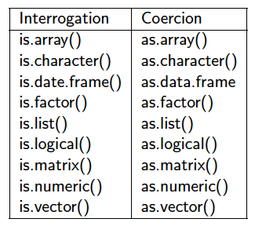

#### Here are some examples of interrogation:

```r
pi <- 3.14

is.integer(pi)
```

```
## [1] FALSE
```

```r
is.numeric(pi)
```

```
## [1] TRUE
```

```r
is.character(pi)
```

```
## [1] FALSE
```

```r
is.logical(pi)
```

```
## [1] FALSE
```

#### Here are some examples of coercion. We coerce variables usually after we read in some data but we also do it when writing functions to process data frames.

```r
pi <- 3.14

as.integer(pi)
```

```
## [1] 3
```

```r
as.character(pi)
```

```
## [1] "3.14"
```

```r
as.numeric(as.character(pi))
```

```
## [1] 3.14
```

#### Here we use both interrogation and coercion to check arguments to a function that computes the mean of a vector.

```r
mymean <- function(x) {
  #
  # Function to compute the mean of a numeric vector
  #
  if (!is.vector(x)) {
    stop("The argument is not a vector")
  }
  if (!is.numeric(x)) {
    print("The arguement is not numeric - Trying to convert to numeric")
    x <- as.numeric(x)
  }
  return(sum(x)/length(x))
}

mymean(c("1","2","3","4"))
```

```
## [1] "The arguement is not numeric - Trying to convert to numeric"
```

```
## [1] 2.5
```

## 5. Vectors

#### Vectors are a fundamental data structure in R. It is absolutely essential that you know how to be productive using vectors. Vectors can have the types described previously, (integer, logical,real, character, factor).

```r
1:10
```

```
##  [1]  1  2  3  4  5  6  7  8  9 10
```

```r
rnorm(10)
```

```
##  [1]  1.9380312 -2.1559735  1.0456353 -1.1799081  0.3808211  0.9937849
##  [7] -1.1476752 -2.7104592  1.6413899 -0.5688923
```

```r
y <- 5.4 # A single assignment

y <- 1:10 # A vector with 10 elements (1 .. 10)

y <- c(1,2,3,4,5,6,7,8,9,10) # Same as above yet using the "c" function
```

Let’s say we have measured the heights of some people. Vectors are perfect for stashing this info. Also - **bracket notation** is the key to working with vectors (and data frames)

```r
height <- c(59,70,66,72,62,66,60,60) # create a vector of 8 heights

height[1:5] # Get first 5 elements
```

```
## [1] 59 70 66 72 62
```

```r
height[5:1] # Get first 5 elements in reverse
```

```
## [1] 62 72 66 70 59
```

```r
height[-1] # Get all but first element
```

```
## [1] 70 66 72 62 66 60 60
```

```r
height[-1:-2] # Get all but first two elements
```

```
## [1] 66 72 62 66 60 60
```

```r
height[c(1,5)] # Get just first and fifth elements
```

```
## [1] 59 62
```

#### If we have a vector we can apply logical tests. This is very powerful

```r
height
```

```
## [1] 59 70 66 72 62 66 60 60
```

```r
height == 72 # Test for values equal to 72
```

```
## [1] FALSE FALSE FALSE  TRUE FALSE FALSE FALSE FALSE
```

```r
height[height == 72]
```

```
## [1] 72
```

```r
# SAME AS
logical.vector <- (height == 72)
logical.vector
```

```
## [1] FALSE FALSE FALSE  TRUE FALSE FALSE FALSE FALSE
```

```r
height[ logical.vector ]
```

```
## [1] 72
```

#### There are operators we can use to combine logical comparisons

```r
# Note use of the "&" / and operator

height[height > 60 & height < 70]
```

```
## [1] 66 62 66
```

```r
height[height > 60 & height <= 70]
```

```
## [1] 70 66 62 66
```

```r
height[height < 60 | height > 70]
```

```
## [1] 59 72
```

```r
height[(height < 60) | (height > 70)]
```

```
## [1] 59 72
```

#### Vectors exist, in part, to help us avoid having t o write ``for loops’’ everytime we want to process a vector and summarize it. Compare the following:

```r
height[height > 60 & height < 70]
```

```
## [1] 66 62 66
```

```r
for (ii in 1:length(height)) {
  if (height[ii] > 60 & height[ii] < 70) {
     print(height[ii])
   }
}
```

```
## [1] 66
## [1] 62
## [1] 66
```

### Example: Weight and height

#### Let’s create a weight vector that corresponds to the height vector. (We measured the same people)

```r
weight <- c(117,165,139,142,126,151,120,166) # weight (in lbs)

weight/100
```

```
## [1] 1.17 1.65 1.39 1.42 1.26 1.51 1.20 1.66
```

```r
sqrt(weight)
```

```
## [1] 10.81665 12.84523 11.78983 11.91638 11.22497 12.28821 10.95445 12.88410
```

```r
weight^2
```

```
## [1] 13689 27225 19321 20164 15876 22801 14400 27556
```

```r
sum((weight-mean(weight))^2)/(length(weight)-1) # The variance formula
```

```
## [1] 363.9286
```

```r
var(weight)
```

```
## [1] 363.9286
```

```r
height <- c(59,70,66,72,62,66,60,60)

weight <- c(117,165,139,142,126,151,120,166)

cor(height,weight) # Are they correlated ?
```

```
## [1] 0.46295
```

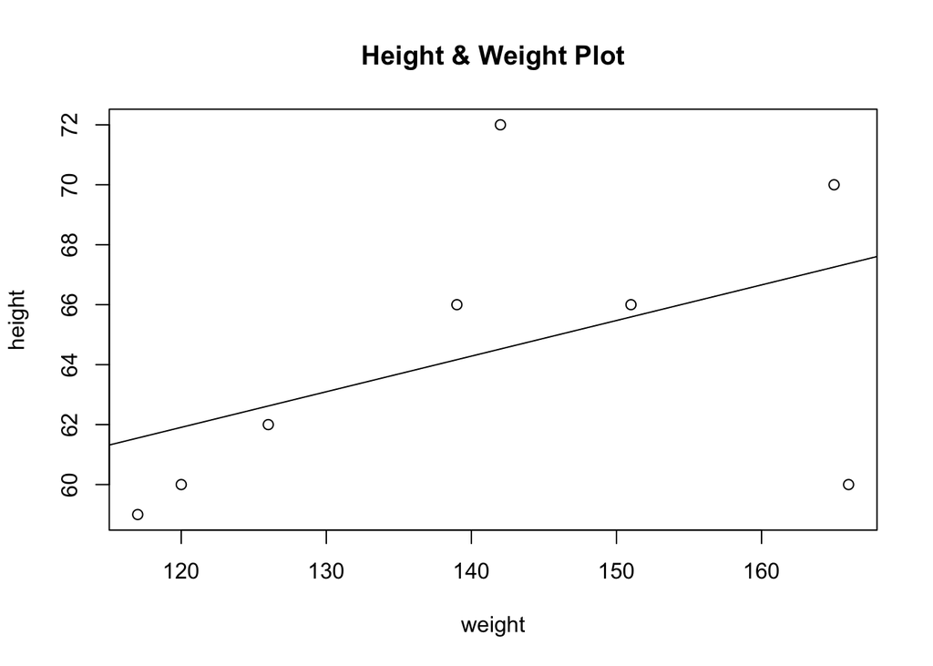

```r
plot(weight,height,main="Height & Weight Plot") # Do a X/Y plot

res <- lm(height ~ weight) # Do a linear regression

abline(res) # Check out the regression line
```

```r
weight <- c(117,165,139,142,126,151,120,166) # weight (in lbs)

new.weights <- weight + 1 # Vector Addition

new.weights
```

```
## [1] 118 166 140 143 127 152 121 167
```

```r
c(weight,new.weights) # Combines the two vectors
```

```
##  [1] 117 165 139 142 126 151 120 166 118 166 140 143 127 152 121 167
```

```r
round(weight/new.weights,2)
```

```
## [1] 0.99 0.99 0.99 0.99 0.99 0.99 0.99 0.99
```

#### An important attribute of a vector is its length. To determine its length, (or set it), one uses the “length” function.

```r
y <- 1:10
length(y) # Length of the entire vector
```

```
## [1] 10
```

```r
vec1 <- 1:5

vec2 <- c(1,3)

vec1 + vec2 # The shorter vector (vec2) is recycled
```

```
## [1] 2 5 4 7 6
```

```r
height <- c(59,70,66,72,62,66,60,60)

# Let's also create a character vector that contains the names of people
# whose heights we measured

my.names <- c("Jacqueline","Frank","Babette","Mario","Adriana",
              "Esteban","Carole","Louis")

names(height) <- my.names

height
```

```
## Jacqueline      Frank    Babette      Mario    Adriana    Esteban
##         59         70         66         72         62         66
##     Carole      Louis
##         60         60
```

#### The `which` command allows us to determine which element number(s) satisfies a condition. If the element has a name then we will also see that listed.

```r
height > 60
```

```
## Jacqueline      Frank    Babette      Mario    Adriana    Esteban
##      FALSE       TRUE       TRUE       TRUE       TRUE       TRUE
##     Carole      Louis
##      FALSE      FALSE
```

```r
which(height > 60)
```

```
##   Frank Babette   Mario Adriana Esteban
##       2       3       4       5       6
```

```r
height[which(height > 60)]
```

```
##   Frank Babette   Mario Adriana Esteban
##      70      66      72      62      66
```

```r
# Note that the element names do not interfere with numeric evaluations

mean(height)
```

```
## [1] 64.375
```

#### The `paste()` function allows us to rapidly generate label names for a vector. For example we can rapdily generate names for observations according to a pattern.

```r
new.names <- paste("ID",1:8,sep="_")

new.names
```

```
## [1] "ID_1" "ID_2" "ID_3" "ID_4" "ID_5" "ID_6" "ID_7" "ID_8"
```

```r
names(height) <- new.names

height
```

```
## ID_1 ID_2 ID_3 ID_4 ID_5 ID_6 ID_7 ID_8
##   59   70   66   72   62   66   60   60
```

#### Missing Values

```r
gender <- c("F","M","F","M","F","M","F","M") # Get their gender

length(gender) # Gives current length of vector
```

```
## [1] 8
```

```r
length(gender) <- 10 # Sets length of the vector

gender # NA represents a missing value
```

```
##  [1] "F" "M" "F" "M" "F" "M" "F" "M" NA  NA
```

```r
is.na(gender)
```

```
##  [1] FALSE FALSE FALSE FALSE FALSE FALSE FALSE FALSE  TRUE  TRUE
```

```r
which(is.na(gender)) # Which elements contain missing values
```

```
## [1]  9 10
```

```r
which(!is.na(gender))
```

```
## [1] 1 2 3 4 5 6 7 8
```

```r
gender[!is.na(gender)] # Get elements which aren't missing
```

```
## [1] "F" "M" "F" "M" "F" "M" "F" "M"
```

#### Here are some of the functions in R that operate on vectors. There are many many more:

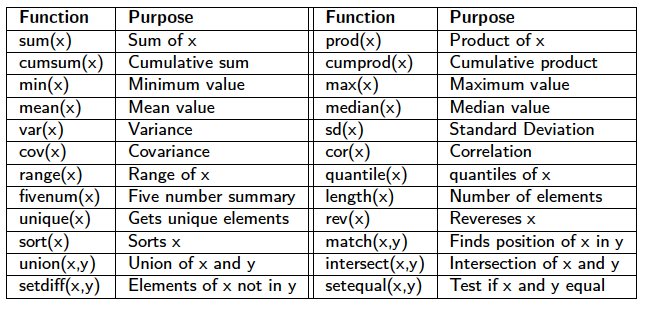

#### Various exmamples

```r
mean(height) # Get the mean
```

```
## [1] 64.375
```

```r
sd(height) # Get standard deviation
```

```
## [1] 4.897157
```

```r
min(height) # Get the minimum
```

```
## [1] 59
```

```r
range(height) # Get the range
```

```
## [1] 59 72
```

```r
length(height) # Vector length
```

```
## [1] 8
```

```r
quantile(height) # Quantiles
```

```
##   0%  25%  50%  75% 100%
##   59   60   64   67   72
```

```r
# Generate 10000 numbers from a Normal distribution

set.seed(123)
my.vals <- rnorm(10000,20,2)   # Mean of 20 and sd of 2

max(my.vals)   # Find max
```

```
## [1] 27.69554
```

```r
which.max(my.vals) # Which element is the max ?
```

```
## [1] 8156
```

```r
my.vals[ which.max(my.vals) ]  # Confirm
```

```
## [1] 27.69554
```

```r
min(my.vals)    # Find min ?
```

```
## [1] 12.30936
```

```r
my.vals[ which.min(my.vals) ]   # Confirm
```

```
## [1] 12.30936
```

```r
x <- 1:16
x[x %% 2 == 0] # Find the even numbers between 1 and 16
```

```
## [1]  2  4  6  8 10 12 14 16
```

#### We want to find the sum of all the elements in x that are less than 5.

```r
x <- 0:10

x[ x < 5 ]
```

```
## [1] 0 1 2 3 4
```

```r
sum( x[x<5] )
```

```
## [1] 10
```

```r
# Find the reverse of x without using the `rev()` function

x[length(x):1]
```

```
##  [1] 10  9  8  7  6  5  4  3  2  1  0
```

#### Given the following vector compute the sum of the 3 largest elements. This is easy by visual inspection but what if the vector had 100,000 or even 1,000,000 elements ?

```r
x <- c(20,22,4,27,9,7,5,19,9,12)

sort(x)
```

```
##  [1]  4  5  7  9  9 12 19 20 22 27
```

```r
rev(sort(x))
```

```
##  [1] 27 22 20 19 12  9  9  7  5  4
```

```r
rev(sort(x))[1:3]
```

```
## [1] 27 22 20
```

```r
sum(rev(sort(x))[1:3])
```

```
## [1] 69
```

### Revisit: Character Vectors

##### Let’s reconsider character vectors

```r
char.vec <- c("here","we","are","now","in","winter")

nchar(char.vec)
```

```
## [1] 4 2 3 3 2 6
```

```r
rev(char.vec) # Reverses the vector
```

```
## [1] "winter" "in"     "now"    "are"    "we"     "here"
```

```r
char.vec[-1] # Omit the first element
```

```
## [1] "we"     "are"    "now"    "in"     "winter"
```

```r
char.vec = c(char.vec,"Its cold") # Append the vector
```

#### R has support for string searching and matching.

```r
char.vec <- c("here","we","are","now","in","winter")

grep("ar",char.vec)
```

```
## [1] 3
```

```r
char.vec[3]
```

```
## [1] "are"
```

```r
grep("ar",char.vec,value=T)
```

```
## [1] "are"
```

```r
grep("^w",char.vec,value=TRUE) # Words that begin with "w"
```

```
## [1] "we"     "winter"
```

```r
grep("w",char.vec, value=TRUE) # Any words that contain "w"
```

```
## [1] "we"     "now"    "winter"
```

```r
grep("w$",char.vec, value=TRUE) # words that end with "w"
```

```
## [1] "now"
```

#### R has support for string searching and matching.

```r
char.vec <- c("here","we","are","now","in","winter")

char.vec[ -grep("ar",char.vec)] # All words NOT containing "ar"
```

```
## [1] "here"   "we"     "now"    "in"     "winter"
```

```r
-grep("ar",char.vec)
```

```
## [1] -3
```

```r
char.vec[-3]
```

```
## [1] "here"   "we"     "now"    "in"     "winter"
```

```r
gsub("here","there",char.vec) # We can change words too !
```

```
## [1] "there"  "we"     "are"    "now"    "in"     "winter"
```

```r
gsub("^w","Z",char.vec) # Replace any "w" at the beginning of a word to Z
```

```
## [1] "here"   "Ze"     "are"    "now"    "in"     "Zinter"
```

```r
grep("AK",myvec)
```

```
## integer(0)
```

```r
grep("AK",myvec,value=T)
```

```
## character(0)
```

```r
# Find all women who do not smoke from any state

grep("0:F",myvec)
```

[output not shown]

```
## integer(0)
```

```r
grep("0:F",myvec,value=T)
```

```
## character(0)
```

```r
grep("M$",myvec)
```

```
## integer(0)
```

```r
grep("M$",myvec,value=T)
```

```
## character(0)
```

```r
# Find all indentifiers that relate to Georgia or Pennsylvania

grep("PA|GA",myvec,value=T)
```

[output not shown]

```
## character(0)
```

```r
# Find all identifiers that relate to any state BUT Georgia

myvec[ -grep("GA",myvec) ]
```

[output not shown]

```
## integer(0)
```

#### Character vectors also show up when we use the `list.files()` function to generate a list of files to be processed.

#### For example let’s say we have some files of the form 001.csv, 002.csv, .. 029.csv. Maybe we want to process some or all of them. First we have to generate a character vector containing the names.

```r
files_to_be_read <- list.files(".","*.csv")

str(files_to_be_read)
```

```
##  chr "msleep_ggplot2.csv"
```

### Manipulate DNA Strings

#### DNA is a series of recurring letters. We can find patterns and “motifs” in stretches of DNA strings.

```r
dna <- c("A","A","C","G","A","C","C","C","G","G","A","T","G","A","C","T","G",
"A","A","C")

# How many Gs are in the string ?

grep("G",dna) # Extracts the elements numbers
```

```
## [1]  4  9 10 13 17
```

```r
dna[ grep("G",dna) ]
```

```
## [1] "G" "G" "G" "G" "G"
```

```r
# OR MORE SIMPLY

grep("G",dna, value = TRUE)
```

```
## [1] "G" "G" "G" "G" "G"
```

```r
length(grep("G",dna, value = TRUE)) # 5 occurrences of G
```

```
## [1] 5
```

#### Let’s look at some special cases that are important to know

```r
dna < c("A","A","C","G","A","C","C","C","G","G","A","T","G","A",
        "C","T","G","A","A","C")
```

```
##  [1] FALSE FALSE FALSE FALSE FALSE FALSE FALSE FALSE FALSE FALSE FALSE
## [12] FALSE FALSE FALSE FALSE FALSE FALSE FALSE FALSE FALSE
```

```r
my.str <- paste(dna,collapse="")

substr(my.str,1,1)
```

```
## [1] "A"
```

```r
substr(my.str,1,2)
```

```
## [1] "AA"
```

```r
substr(my.str,1,3)
```

```
## [1] "AAC"
```

```r
substr(my.str,1,4)
```

```
## [1] "AACG"
```

```r
gsub("TG","G",my.str)
```

```
## [1] "AACGACCCGGAGACGAAC"
```

```r
my.str
```

```
## [1] "AACGACCCGGATGACTGAAC"
```

```r
substr(my.str,2,8)
```

```
## [1] "ACGACCC"
```

```r
substr(my.str,2,8) = "TTTTTTT"
my.str
```

```
## [1] "ATTTTTTTGGATGACTGAAC"
```

```r
nchar(my.str)
```

```
## [1] 20
```

```r
for (ii in 1:nchar(my.str)) {
  cat(substr(my.str,ii,ii))
}
```

```
## ATTTTTTTGGATGACTGAAC
```

```r
for (ii in nchar(my.str):1) {
  cat(substr(my.str,ii,ii))
}
```

```
## CAAGTCAGTAGGTTTTTTTA
```

```r
# Recipe to get the "collapsed" string back into a vector with
# separate elements for each letter
unlist(strsplit(my.str,""))
```

```
##  [1] "A" "T" "T" "T" "T" "T" "T" "T" "G" "G" "A" "T" "G" "A" "C" "T" "G"
## [18] "A" "A" "C"
```